# Clima do Paraná: Guarapuava

NASA POWER, dados horários agregados por dia

# 1. Estatística descritiva

| variavel | media | mediana | moda | minimo | maximo | amplitude | variancia | desvio_pad | cv_pct | q1 | q3 | iqr |
| --- | --- | --- | --- | --- | --- | --- | --- | --- | --- | --- | --- | --- |
| Temperatura média (°C) | 17,72 | 18,48 | 20,5 | 3,05 | 25,54 | 22,49 | 16,24 | 4,03 | 22,74 | 14,99 | 20,80 | 5,81 |
| Temperatura máxima (°C) | 23,34 | 23,83 | 26,6 | 7,87 | 32,83 | 24,96 | 17,53 | 4,19 | 17,93 | 20,65 | 26,39 | 5,74 |
| Temperatura mínima (°C) | 13,03 | 13,64 | 16,3 | -3,24 | 20,80 | 24,04 | 18,19 | 4,27 | 32,73 | 10,26 | 16,31 | 6,06 |
| Ponto de orvalho (°C) | 13,55 | 13,99 | 15,6 | -5,51 | 21,92 | 27,43 | 18,38 | 4,29 | 31,63 | 10,96 | 16,88 | 5,91 |
| Chuva (mm/dia) | 4,11 | 0,54 | 0,0 | 0,00 | 105,86 | 105,86 | 72,46 | 8,51 | 207,31 | 0,01 | 4,30 | 4,29 |
| Umidade (%) | 79,45 | 80,49 | 80,7 | 47,74 | 99,10 | 51,36 | 96,48 | 9,82 | 12,36 | 73,37 | 86,55 | 13,18 |
| Radiação (MJ/m²/dia) | 16,93 | 16,90 | 20,0 | 1,08 | 33,31 | 32,23 | 48,15 | 6,94 | 40,98 | 12,34 | 21,80 | 9,47 |
| Vento a 2 m (m/s) | 0,08 | 0,04 | 0,0 | 0,00 | 0,57 | 0,57 | 0,01 | 0,11 | 130,25 | 0,00 | 0,12 | 0,11 |
| DPV (kPa) | 0,52 | 0,46 | 0,4 | 0,01 | 1,86 | 1,85 | 0,10 | 0,31 | 58,95 | 0,31 | 0,67 | 0,37 |

# 2. Gráficos

## 2.1 Distribuição da temperatura média diária

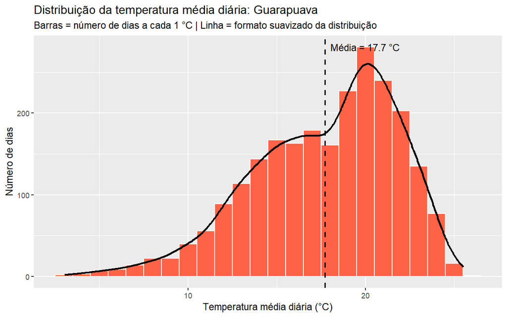

## 2.2 Dias por intensidade de chuva

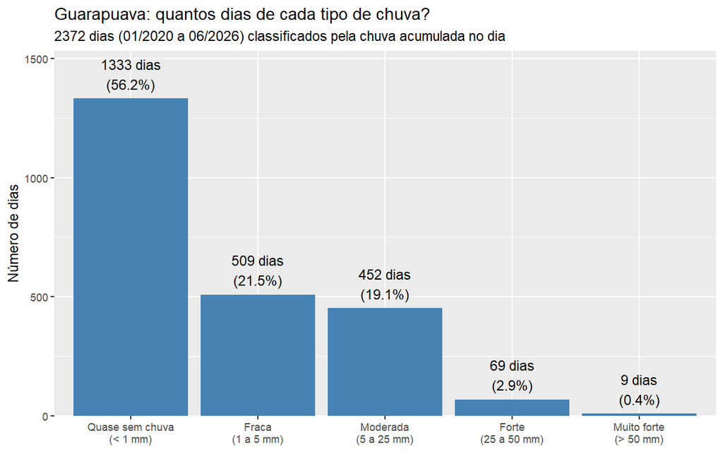

## 2.3 Temperatura média por mês

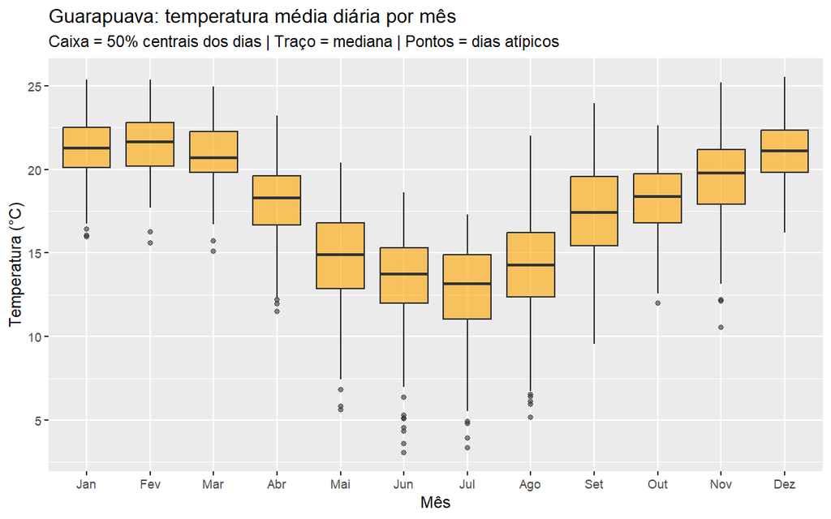

## 2.4 Temperatura ao longo do tempo

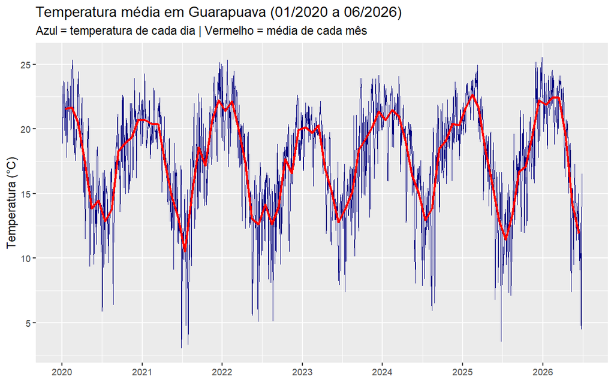

## 2.5 Radiação solar × temperatura

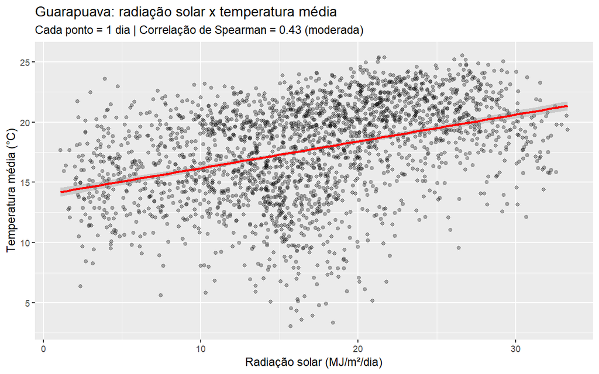

## 2.6 Temperaturas máxima, média e mínima por mês

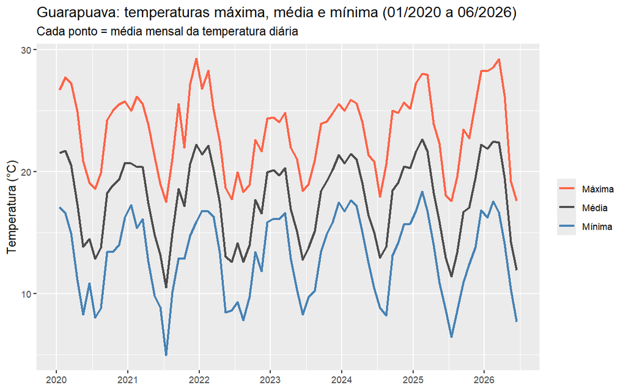

## 2.7 Velocidade do vento por mês

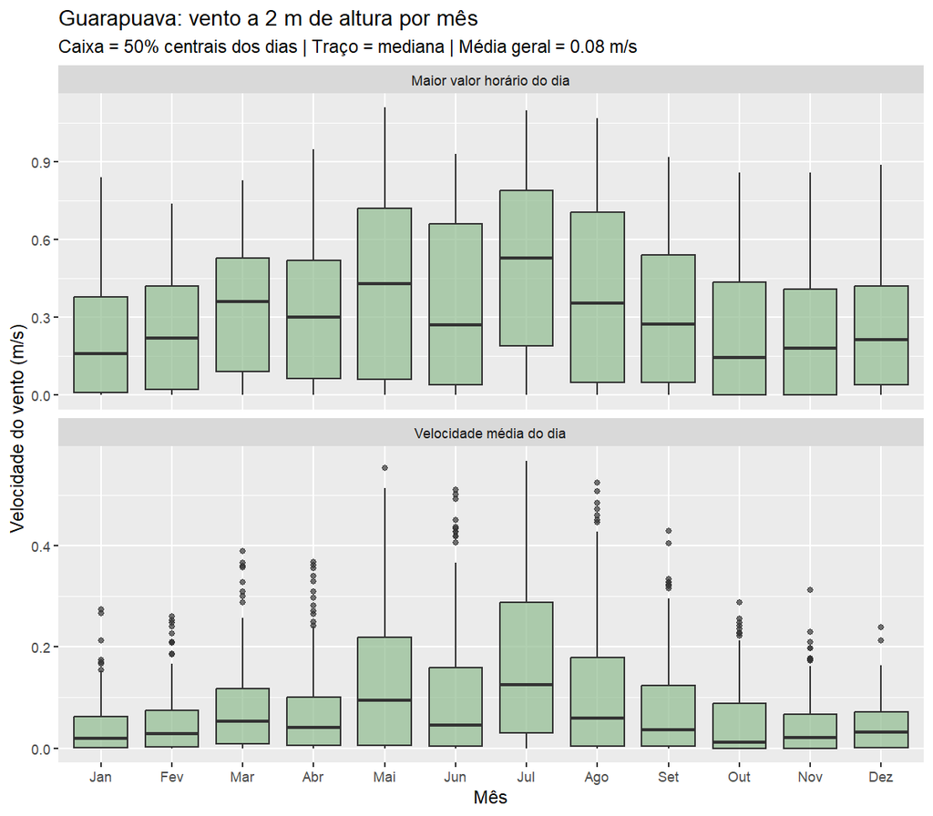

# 3. Teste de normalidade (Shapiro-Wilk)

| Variável | W | p-valor | Decisão |
| --- | --- | --- | --- |
| Temperatura média (°C) | 0.967 | < 0,001 | Não normal (rejeita H0) |
| Temperatura máxima (°C) | 0.985 | < 0,001 | Não normal (rejeita H0) |
| Temperatura mínima (°C) | 0.964 | < 0,001 | Não normal (rejeita H0) |
| Ponto de orvalho (°C) | 0.965 | < 0,001 | Não normal (rejeita H0) |
| Chuva (mm/dia) | 0.526 | < 0,001 | Não normal (rejeita H0) |
| Umidade (%) | 0.982 | < 0,001 | Não normal (rejeita H0) |
| Radiação (MJ/m²/dia) | 0.991 | < 0,001 | Não normal (rejeita H0) |
| Vento a 2 m (m/s) | 0.765 | < 0,001 | Não normal (rejeita H0) |
| DPV (kPa) | 0.932 | < 0,001 | Não normal (rejeita H0) |

## Q-Q plots

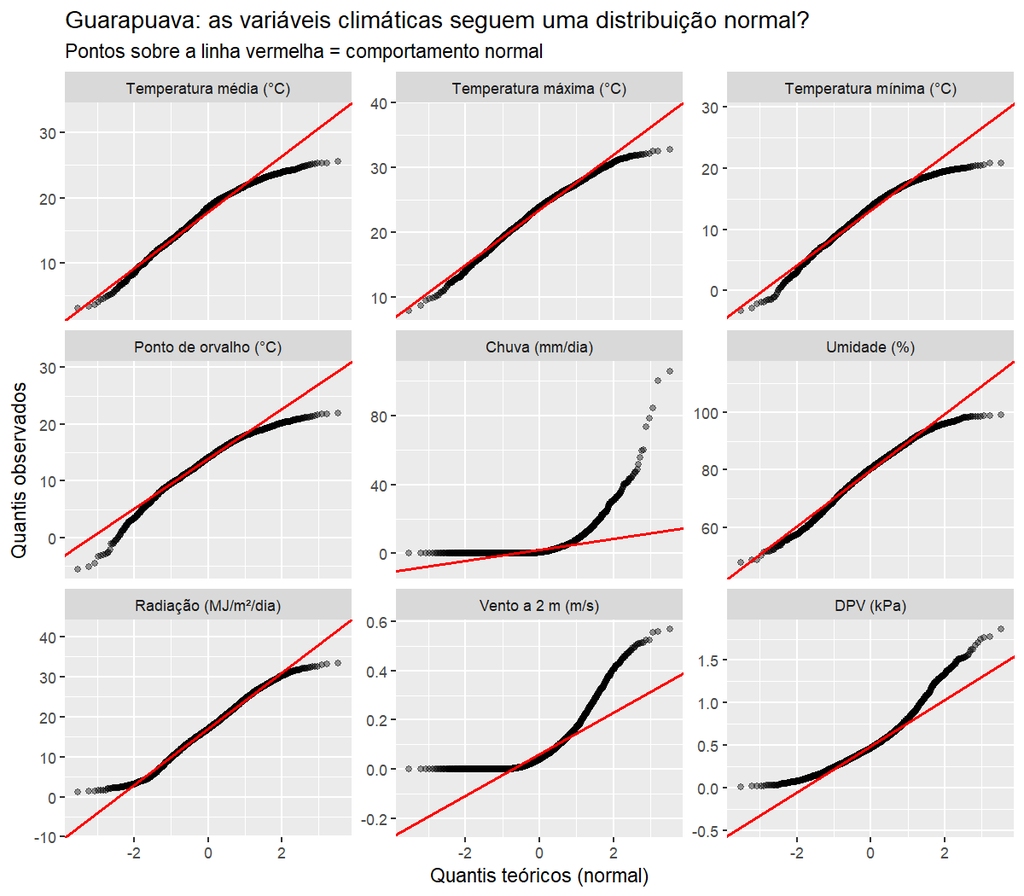

# 4. Teste de correlação (Spearman)

H0: não há correlação (rho = 0). H1: há correlação (rho ≠ 0). Escala de |rho|: 0,00-0,19 muito fraca; 0,20-0,39 fraca; 0,40-0,69 moderada; 0,70-0,89 forte; 0,90-1,00 muito forte.

Dos 36 pares, **35 são significativos** (p < 0,05).

| Par | rho | p-valor | Força | Sentido | Decisão |
| --- | --- | --- | --- | --- | --- |
| Temp. média × Temp. máx. | 0.93 | < 0,001 | Muito forte | Positiva | Correlação significativa |
| Temp. média × Temp. mín. | 0.93 | < 0,001 | Muito forte | Positiva | Correlação significativa |
| Temp. mín. × P. orvalho | 0.93 | < 0,001 | Muito forte | Positiva | Correlação significativa |
| Umidade × DPV | -0.89 | < 0,001 | Forte | Negativa | Correlação significativa |
| Temp. média × P. orvalho | 0.82 | < 0,001 | Forte | Positiva | Correlação significativa |
| Temp. máx. × Temp. mín. | 0.75 | < 0,001 | Forte | Positiva | Correlação significativa |
| Temp. máx. × DPV | 0.73 | < 0,001 | Forte | Positiva | Correlação significativa |
| Radiação × DPV | 0.71 | < 0,001 | Forte | Positiva | Correlação significativa |
| Chuva × Umidade | 0.61 | < 0,001 | Moderada | Positiva | Correlação significativa |
| Umidade × Radiação | -0.61 | < 0,001 | Moderada | Negativa | Correlação significativa |
| Temp. máx. × P. orvalho | 0.60 | < 0,001 | Moderada | Positiva | Correlação significativa |
| P. orvalho × Chuva | 0.58 | < 0,001 | Moderada | Positiva | Correlação significativa |
| Temp. máx. × Radiação | 0.57 | < 0,001 | Moderada | Positiva | Correlação significativa |
| Temp. média × DPV | 0.51 | < 0,001 | Moderada | Positiva | Correlação significativa |
| Temp. mín. × Chuva | 0.46 | < 0,001 | Moderada | Positiva | Correlação significativa |
| Temp. média × Radiação | 0.43 | < 0,001 | Moderada | Positiva | Correlação significativa |
| Chuva × DPV | -0.43 | < 0,001 | Moderada | Negativa | Correlação significativa |
| P. orvalho × Umidade | 0.42 | < 0,001 | Moderada | Positiva | Correlação significativa |
| Chuva × Radiação | -0.40 | < 0,001 | Moderada | Negativa | Correlação significativa |
| Temp. máx. × Umidade | -0.38 | < 0,001 | Fraca | Negativa | Correlação significativa |
| Chuva × Vento | -0.34 | < 0,001 | Fraca | Negativa | Correlação significativa |
| Temp. média × Chuva | 0.28 | < 0,001 | Fraca | Positiva | Correlação significativa |
| Temp. mín. × DPV | 0.23 | < 0,001 | Fraca | Positiva | Correlação significativa |
| Umidade × Vento | -0.22 | < 0,001 | Fraca | Negativa | Correlação significativa |
| Temp. mín. × Radiação | 0.21 | < 0,001 | Fraca | Positiva | Correlação significativa |
| Vento × DPV | 0.20 | < 0,001 | Fraca | Positiva | Correlação significativa |
| Temp. mín. × Vento | -0.18 | < 0,001 | Muito fraca | Negativa | Correlação significativa |
| P. orvalho × Vento | -0.16 | < 0,001 | Muito fraca | Negativa | Correlação significativa |
| Temp. mín. × Umidade | 0.15 | < 0,001 | Muito fraca | Positiva | Correlação significativa |
| Radiação × Vento | 0.14 | < 0,001 | Muito fraca | Positiva | Correlação significativa |
| Temp. média × Umidade | -0.13 | < 0,001 | Muito fraca | Negativa | Correlação significativa |
| Temp. máx. × Vento | 0.08 | < 0,001 | Muito fraca | Positiva | Correlação significativa |
| P. orvalho × Radiação | 0.06 | 0,004 | Muito fraca | Positiva | Correlação significativa |
| Temp. média × Vento | -0.05 | 0,019 | Muito fraca | Negativa | Correlação significativa |
| Temp. máx. × Chuva | 0.05 | 0,018 | Muito fraca | Positiva | Correlação significativa |
| P. orvalho × DPV | -0.03 | 0,210 | Muito fraca | Negativa | Sem evidência de correlação |

## Mapa de calor

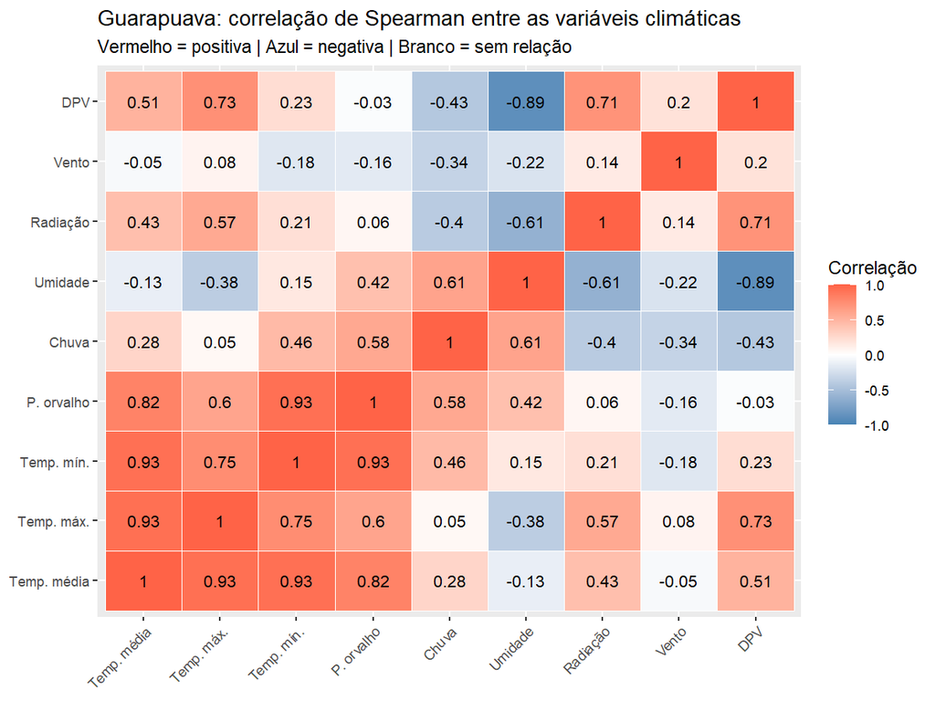

## Pearson (apenas para comparação: radiação × temperatura)

r = 0.38 (IC 95%: 0.35 a 0.42), p-valor < 0,001.

# Observações

- O NASA POWER é derivado de satélites e modelos (grade de ~50 km), não de estações; a chuva é a variável menos confiável.
- Os dados são **horários** (hora solar local) e foram agregados por dia: média para temperatura, umidade, vento, ponto de orvalho e DPV; soma dos valores horários para chuva (mm) e radiação (MJ/m²); máximo e mínimo dos valores horários para `temp_max`, `temp_min` e `vento_max`. Como cada valor horário já é uma média de uma hora, os extremos diários são um pouco mais suaves que os de uma estação.
- O DPV e o ponto de orvalho são calculados **hora a hora** (fórmula de Magnus) e só depois viram média diária, o que evita o viés de calcular a partir de médias diárias. Ainda assim, suas correlações com temperatura e umidade são em parte matemáticas.
- O período vai de 2020 até a data mais recente disponível (a NASA tem alguns dias de atraso). O último mês costuma estar incompleto, e a sazonalidade deixa os p-valores otimistas. Correlação não implica causa.